# M515 Ethical Issues for AI (SS0325)

## Tuthor: Dr. Mahmoudreza Babaei

### Student Name: Ehsan Shahabirad

### Student Number: GH1028696

## Project GitHub link: https://github.com/EhsanShahabiRad/Ethical-Issues-for-AI

[figure not shown]

## Why I Chose These Business Problems and Datasets to Work on in This Project:

### 1. Clear Ethical Relevance

##### The telemarketing dataset contains sensitive demographic attributes (e.g., education, marital status, age). These features let us investigate fairness questions such as disparate impact and potential discrimination in automated campaign decisions—core topics of an “Ethical Issues for AI” course.

#### 2. Documented Real-World Impact

##### Banks routinely use similar models to decide whom to target for financial products. A biased prediction can translate directly into unequal access to credit or predatory marketing, making ethical analysis more than an academic exercise.

#### 3. Rich Mix of Feature Types

##### With 20 inputs—both categorical and numerical—the dataset forces us to confront practical preprocessing choices (one-hot vs. ordinal encoding, scaling, handling rare categories) that can themselves introduce or mitigate bias.

#### 4. Built-In Class Imbalance

##### The “yes” response rate is low, mirroring many real decision-making tasks where positive outcomes are scarce. Addressing imbalance (e.g., up-sampling, class-weighted losses) provides a natural setting to discuss ethical trade-offs between overall accuracy and minority-class performance.

#### 5. Fairness-Focused Experiment Design

##### By training models with and without sensitive attributes and comparing group-wise metrics (positive-prediction rate, confusion-matrix disparities, variance reduction), we can quantify how feature selection affects fairness—an explicit learning objective for this course.

#### 6. Model Diversity for Comparative Ethics

##### Logistic Regression, Decision Trees, and Random Forests differ in transparency and interpretability. Exploring all three lets us weigh ethical considerations such as explainability vs. performance and assess how model complexity influences bias.

#### 7. Scalability & Reproducibility

##### The full dataset (~41 k rows) is small enough for rapid iteration in a notebook yet large enough to reveal non-trivial ethical patterns. Using public, version-controlled data (Kaggle repository) ensures that the entire fairness workflow is reproducible and auditable.

# Step 1 – Business & Ethical Problem Understanding

## 1.1. Business Objective

#### A retail bank wants to increase the conversion rate of its tele-marketing campaigns for term-deposit products. Each call costs time and money; therefore, contacting the customers most likely to subscribe improves both revenue and operational efficiency.

## 1.2. Ethical Objective

#### We must train the model with fairness as a first-class target, not a side check. During development we measure bias for every protected group, apply mitigation (re-sampling, re-weighting, or dropping sensitive features) when disparities appear, and pick the version that keeps accuracy high and group gaps low. Validating these fairness metrics on a hold-out set—and documenting every step—ensures the final system treats all customers as equitably as the data allow.

## 1.3. Stakeholders & Potential Harms

#### Customers benefit from relevant, timely offers but risk intrusive solicitation or exclusion from beneficial products if the model is biased. The bank gains higher profit and lower costs, yet faces fines and reputational damage if unfairness is uncovered. Regulators seek evidence of fair-lending compliance and may impose sanctions when disparate impact appears. Society at large depends on credit markets that distribute opportunity equitably; biased targeting can reinforce existing inequalities.

# Step 2 – Data Collection

#### I use the dataset "bank-additional-full.csv" from "https://www.kaggle.com/datasets/tunguz/bank-marketing-data-set/data?select=bank-additional-full.csv", which contains all examples and 20 input features, making it the most comprehensive version of the dataset related to the telemarketing campaigns

## Imports

```python
import pandas as pd
import numpy as np
import matplotlib.pyplot as plt
from sklearn.model_selection import train_test_split
from sklearn.preprocessing import StandardScaler, OneHotEncoder
from sklearn.compose import ColumnTransformer
from sklearn.utils import shuffle
from sklearn.linear_model import LogisticRegression
from sklearn.metrics import accuracy_score, precision_score, recall_score
from sklearn.model_selection import GridSearchCV
from sklearn.tree import DecisionTreeClassifier
from sklearn.ensemble import RandomForestClassifier
from sklearn.svm import SVC
from sklearn.metrics import accuracy_score, confusion_matrix, classification_report
from sklearn.metrics import accuracy_score, confusion_matrix
```

### Load Dataset

```python
df = pd.read_csv("https://raw.githubusercontent.com/EhsanShahabiRad/Ethical-Issues-for-AI/refs/heads/main/Datasets/bank-additional-full.csv", sep=";")
df.head()
```

|  | age | job | marital | education | default | housing | loan | contact | month | day_of_week | ... | campaign | pdays | previous | poutcome | emp.var.rate | cons.price.idx | cons.conf.idx | euribor3m | nr.employed | y |
| --- | --- | --- | --- | --- | --- | --- | --- | --- | --- | --- | --- | --- | --- | --- | --- | --- | --- | --- | --- | --- | --- |
| 0 | 56 | housemaid | married | basic.4y | no | no | no | telephone | may | mon | ... | 1 | 999 | 0 | nonexistent | 1.1 | 93.994 | -36.4 | 4.857 | 5191.0 | no |
| 1 | 57 | services | married | high.school | unknown | no | no | telephone | may | mon | ... | 1 | 999 | 0 | nonexistent | 1.1 | 93.994 | -36.4 | 4.857 | 5191.0 | no |
| 2 | 37 | services | married | high.school | no | yes | no | telephone | may | mon | ... | 1 | 999 | 0 | nonexistent | 1.1 | 93.994 | -36.4 | 4.857 | 5191.0 | no |
| 3 | 40 | admin. | married | basic.6y | no | no | no | telephone | may | mon | ... | 1 | 999 | 0 | nonexistent | 1.1 | 93.994 | -36.4 | 4.857 | 5191.0 | no |
| 4 | 56 | services | married | high.school | no | no | yes | telephone | may | mon | ... | 1 | 999 | 0 | nonexistent | 1.1 | 93.994 | -36.4 | 4.857 | 5191.0 | no |

5 rows × 21 columns

# Step 3 – Data Exploration

#### Check for missing values

```python
print(df.isnull().sum())
```

```
age               0
job               0
marital           0
education         0
default           0
housing           0
loan              0
contact           0
month             0
day_of_week       0
duration          0
campaign          0
pdays             0
previous          0
poutcome          0
emp.var.rate      0
cons.price.idx    0
cons.conf.idx     0
euribor3m         0
nr.employed       0
y                 0
dtype: int64
```

#### Check for duplicate entries

```python
print(df.duplicated().sum())
```

```
12
```

#### Check for class imbalance

```python
print(df['y'].value_counts())
```

```
y
no     36548
yes     4640
Name: count, dtype: int64
```

#### Visualize the distribution of the target variable

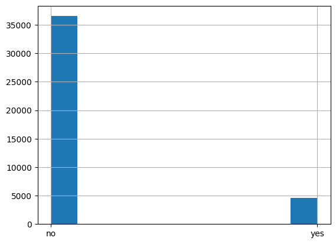

```python
df["y"].hist()
```

#### Visualize the distribution of the 'duration' feature

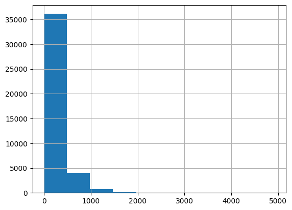

```python
df["duration"].hist()
```

#### Visualize the distribution of the 'day_of_week' feature

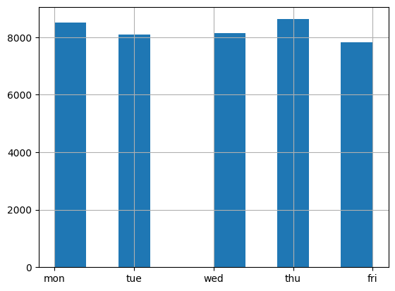

```python
df["day_of_week"].hist()
```

#### Visualize the distribution of the 'contact' feature

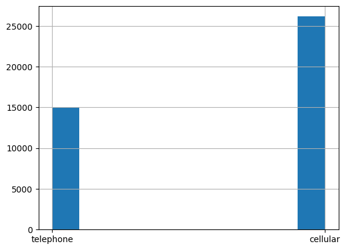

```python
df["contact"].hist()
```

#### Visualize the distribution of numerical features

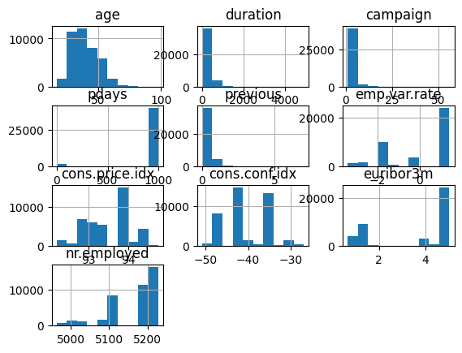

```python
numerical_features = df.select_dtypes(include=['int64', 'float64']).columns
df[numerical_features].hist()
plt.show()
```

# Step 4 – Data Preprocessing

#### remove duplicate entries. although there are only 12 duplicate values, i decided to remove them

```python
print("Number of duplicate entries before dropping:", df.duplicated().sum())
df = df.drop_duplicates()
print("Number of duplicate entries after dropping:", df.duplicated().sum())
```

```
Number of duplicate entries before dropping: 12
Number of duplicate entries after dropping: 0
```

#### Drop the 'duration' and 'day_of_week' columns as they are not useful. Although it might seems that the contact feature is relevant, after droping it, the results slightly got better

```python
df = df.drop(columns=['duration', 'day_of_week', 'contact'])
```

#### Identify categorical and numerical feature

```python
categorical_features = df.select_dtypes(include=['object']).columns
numerical_features = df.select_dtypes(include=['int64', 'float64']).columns
```

#### Split the data into features and target; Also, Convert target to binary

```python
X = df.drop('y', axis=1)
y = df['y'].apply(lambda x: 1 if x == 'yes' else 0)
```

#### Address class imbalance using resampling

```python
df_majority = df[y == 0]
df_minority = df[y == 1]

df_minority_upsampled = df_minority.sample(len(df_majority), replace=True, random_state=42)
df_upsampled = pd.concat([df_majority, df_minority_upsampled])
```

#### Split the upsampled data into features and target

```python
X_resampled = df_upsampled.drop('y', axis=1)
y_resampled = df_upsampled['y'].apply(lambda x: 1 if x == 'yes' else 0)
```

#### Shuffle the dataset

```python
X_resampled, y_resampled = shuffle(X_resampled, y_resampled, random_state=33)
```

### Split the resampled data into training and test sets

```python
X_train, X_test, y_train, y_test = train_test_split(X_resampled, y_resampled, test_size=0.2, random_state=33)
# i'm usin random_state=33 so i always get the same training and test set everytime i run the code. it can be removed, also the number can set to any number
```

# Step 5 – Feature Engineering

#### Identify categorical and numerical features

```python
categorical_features = X_train.select_dtypes(include=['object']).columns
numerical_features = X_train.select_dtypes(include=['int64', 'float64']).columns
```

#### Applying Transformations

```python
ct = ColumnTransformer([
    ("standard_scaling", StandardScaler(), numerical_features),
    ("one_hot_encoding", OneHotEncoder(handle_unknown="ignore"), categorical_features)
])
```

#### Fitting and Transforming the Training Data

```python
X_train_processed = ct.fit_transform(X_train)
X_test_processed = ct.transform(X_test)
```

#### Display shapes of the preprocessed datasets

```python
print("Training Set Shape:", X_train_processed.shape, y_train.shape)
print("Test Set Shape:", X_test_processed.shape, y_test.shape)
```

```
Training Set Shape: (58459, 55) (58459,)
Test Set Shape: (14615, 55) (14615,)
```

# Step 6 – Model Training

## Algorithm Selection

#### I use logistic regression as a clear, interpretable baseline; decision trees to model nonlinear feature interactions while remaining explainable; and random forests to boost accuracy and stability through ensemble learning

### Initialize models

```python
models = {
    "Logistic Regression": LogisticRegression(max_iter=1000),
    "Random Forest": RandomForestClassifier(),
    "Decision Tree": DecisionTreeClassifier()
}
```

### Train the model on the training set

```python
for name, model in models.items():
    model.fit(X_train_processed, y_train)
    y_pred = model.predict(X_test_processed)
    acc = accuracy_score(y_test, y_pred)
    cm = confusion_matrix(y_test, y_pred, labels=[0, 1])
    tn, fp, fn, tp = cm.ravel()

    print(f"\n{name} Accuracy: {acc:.4f}\n")

    print(f"{name} Confusion Matrix:")
    print("                         Predicted: No       Predicted: Yes")
    print(f"Actual: No               {tn:<20}{fp}")
    print(f"Actual: Yes              {fn:<20}{tp}\n")

    print("Details:")
    print(f"TN (True Negative):     {tn} - correctly predicted No")
    print(f"FP (False Positive):    {fp} - predicted Yes when actually No")
    print(f"FN (False Negative):    {fn} - predicted No when actually Yes")
    print(f"TP (True Positive):     {tp} - correctly predicted Yes")
    print("-" * 60)
```

```
Logistic Regression Accuracy: 0.7377

Logistic Regression Confusion Matrix:
                         Predicted: No       Predicted: Yes
Actual: No               6248                1024
Actual: Yes              2809                4534

Details:
TN (True Negative):     6248 - correctly predicted No
FP (False Positive):    1024 - predicted Yes when actually No
FN (False Negative):    2809 - predicted No when actually Yes
TP (True Positive):     4534 - correctly predicted Yes
------------------------------------------------------------

Random Forest Accuracy: 0.9623

Random Forest Confusion Matrix:
                         Predicted: No       Predicted: Yes
Actual: No               6734                538
Actual: Yes              13                  7330

Details:
TN (True Negative):     6734 - correctly predicted No
FP (False Positive):    538 - predicted Yes when actually No
FN (False Negative):    13 - predicted No when actually Yes
TP (True Positive):     7330 - correctly predicted Yes
------------------------------------------------------------

Decision Tree Accuracy: 0.9388

Decision Tree Confusion Matrix:
                         Predicted: No       Predicted: Yes
Actual: No               6398                874
Actual: Yes              20                  7323

Details:
TN (True Negative):     6398 - correctly predicted No
FP (False Positive):    874 - predicted Yes when actually No
FN (False Negative):    20 - predicted No when actually Yes
TP (True Positive):     7323 - correctly predicted Yes
------------------------------------------------------------
```

# Step 7 – Fairness Evaluation

## I assume Education feature as a sensetive feature and try to make system fair by training models without education field

### show bias base on education

```python
attribute = 'education'
unique_groups = X_test[attribute].unique()

print(f"\n--- Group-wise Positive Prediction Rates by '{attribute}' ---")
for name, model in models.items():
    print(f"\n--- Group-wise Positive Prediction Rates by '{attribute}' for {name} ---")
    for group in unique_groups:
        idx = X_test[attribute] == group
        X_group = X_test.loc[idx]
        X_group_transformed = ct.transform(X_group)

        y_pred_group = model.predict(X_group_transformed)
        pos_rate = np.mean(y_pred_group)
        print(f"{group}: Positive Prediction Rate = {pos_rate:.4f}  (n={len(y_pred_group)})")
```

```
--- Group-wise Positive Prediction Rates by 'education' ---

--- Group-wise Positive Prediction Rates by 'education' for Logistic Regression ---
university.degree: Positive Prediction Rate = 0.4795  (n=4818)
high.school: Positive Prediction Rate = 0.3580  (n=3355)
basic.6y: Positive Prediction Rate = 0.2085  (n=710)
professional.course: Positive Prediction Rate = 0.3788  (n=1819)
basic.9y: Positive Prediction Rate = 0.2040  (n=1838)
basic.4y: Positive Prediction Rate = 0.3509  (n=1385)
unknown: Positive Prediction Rate = 0.5015  (n=680)
illiterate: Positive Prediction Rate = 0.8000  (n=10)

--- Group-wise Positive Prediction Rates by 'education' for Random Forest ---
university.degree: Positive Prediction Rate = 0.6133  (n=4818)
high.school: Positive Prediction Rate = 0.5121  (n=3355)
basic.6y: Positive Prediction Rate = 0.4211  (n=710)
professional.course: Positive Prediction Rate = 0.5476  (n=1819)
basic.9y: Positive Prediction Rate = 0.4391  (n=1838)
basic.4y: Positive Prediction Rate = 0.4982  (n=1385)
unknown: Positive Prediction Rate = 0.5809  (n=680)
illiterate: Positive Prediction Rate = 0.8000  (n=10)

--- Group-wise Positive Prediction Rates by 'education' for Decision Tree ---
university.degree: Positive Prediction Rate = 0.6295  (n=4818)
high.school: Positive Prediction Rate = 0.5404  (n=3355)
basic.6y: Positive Prediction Rate = 0.4521  (n=710)
professional.course: Positive Prediction Rate = 0.5668  (n=1819)
basic.9y: Positive Prediction Rate = 0.4739  (n=1838)
basic.4y: Positive Prediction Rate = 0.5119  (n=1385)
unknown: Positive Prediction Rate = 0.6044  (n=680)
illiterate: Positive Prediction Rate = 0.8000  (n=10)
```

### Removing Education Field

```python
X_train_no_edu = X_train.drop(columns=['education'])
X_test_no_edu = X_test.drop(columns=['education'])
```

#### Fairness Evaluation After Removing 'education'

```python
print("\n\n=== Training Models WITHOUT 'education' Attribute ===")

# Re-transform without 'education'
categorical_features_wo_edu = X_train_no_edu.select_dtypes(include=['object']).columns
numerical_features_wo_edu = X_train_no_edu.select_dtypes(include=['int64', 'float64']).columns

ct_no_edu = ColumnTransformer([
    ("standard_scaling", StandardScaler(), numerical_features_wo_edu),
    ("one_hot_encoding", OneHotEncoder(handle_unknown="ignore"), categorical_features_wo_edu)
])

X_train_no_edu_processed = ct_no_edu.fit_transform(X_train_no_edu)
X_test_no_edu_processed = ct_no_edu.transform(X_test_no_edu)

models_no_edu = {
    "Logistic Regression": LogisticRegression(max_iter=1000),
    "Random Forest": RandomForestClassifier(),
    "Decision Tree": DecisionTreeClassifier()
}

for name, model in models_no_edu.items():
    model.fit(X_train_no_edu_processed, y_train)
    y_pred = model.predict(X_test_no_edu_processed)
    acc = accuracy_score(y_test, y_pred)
    cm = confusion_matrix(y_test, y_pred, labels=[0, 1])
    tn, fp, fn, tp = cm.ravel()

    print(f"\n{name} Accuracy (without education): {acc:.4f}\n")
    print(f"{name} Confusion Matrix (no education):")
    print("                         Predicted: No       Predicted: Yes")
    print(f"Actual: No               {tn:<20}{fp}")
    print(f"Actual: Yes              {fn:<20}{tp}\n")

    print("Details:")
    print(f"TN (True Negative):     {tn} - correctly predicted No")
    print(f"FP (False Positive):    {fp} - predicted Yes when actually No")
    print(f"FN (False Negative):    {fn} - predicted No when actually Yes")
    print(f"TP (True Positive):     {tp} - correctly predicted Yes")
    print("-" * 60)

# Evaluate fairness across education groups (even though 'education' was removed)
df_test_no_edu = X_test_no_edu.copy()
df_test_no_edu['education'] = X_test['education']
df_test_no_edu['y_true'] = y_test
df_test_no_edu['y_pred'] = models_no_edu["Logistic Regression"].predict(X_test_no_edu_processed)


print("\n--- Group-wise Positive Prediction Rates by 'education' (models WITHOUT 'education' feature) ---")

edu_values = X_test['education'].unique()

for name, model in models_no_edu.items():
    print(f"\n{name}")

    y_pred_all = model.predict(X_test_no_edu_processed)

    df_tmp = pd.DataFrame({
        'education': X_test['education'],
        'y_pred':    y_pred_all
    })

    for group in edu_values:
        mask  = df_tmp['education'] == group
        rate  = df_tmp.loc[mask, 'y_pred'].mean()
        n     = mask.sum()
        print(f"{group:20}: Positive Prediction Rate = {rate:.4f}  (n={n})")
```

```
=== Training Models WITHOUT 'education' Attribute ===

Logistic Regression Accuracy (without education): 0.7381

Logistic Regression Confusion Matrix (no education):
                         Predicted: No       Predicted: Yes
Actual: No               6266                1006
Actual: Yes              2821                4522

Details:
TN (True Negative):     6266 - correctly predicted No
FP (False Positive):    1006 - predicted Yes when actually No
FN (False Negative):    2821 - predicted No when actually Yes
TP (True Positive):     4522 - correctly predicted Yes
------------------------------------------------------------

Random Forest Accuracy (without education): 0.9562

Random Forest Confusion Matrix (no education):
                         Predicted: No       Predicted: Yes
Actual: No               6646                626
Actual: Yes              14                  7329

Details:
TN (True Negative):     6646 - correctly predicted No
FP (False Positive):    626 - predicted Yes when actually No
FN (False Negative):    14 - predicted No when actually Yes
TP (True Positive):     7329 - correctly predicted Yes
------------------------------------------------------------

Decision Tree Accuracy (without education): 0.9416

Decision Tree Confusion Matrix (no education):
                         Predicted: No       Predicted: Yes
Actual: No               6434                838
Actual: Yes              16                  7327

Details:
TN (True Negative):     6434 - correctly predicted No
FP (False Positive):    838 - predicted Yes when actually No
```

[output cut: 20 more lines]

```
professional.course : Positive Prediction Rate = 0.5558  (n=1819)
basic.9y            : Positive Prediction Rate = 0.4494  (n=1838)
basic.4y            : Positive Prediction Rate = 0.4989  (n=1385)
unknown             : Positive Prediction Rate = 0.5853  (n=680)
illiterate          : Positive Prediction Rate = 0.8000  (n=10)

Decision Tree
university.degree   : Positive Prediction Rate = 0.6264  (n=4818)
high.school         : Positive Prediction Rate = 0.5395  (n=3355)
basic.6y            : Positive Prediction Rate = 0.4465  (n=710)
professional.course : Positive Prediction Rate = 0.5662  (n=1819)
basic.9y            : Positive Prediction Rate = 0.4755  (n=1838)
basic.4y            : Positive Prediction Rate = 0.5083  (n=1385)
unknown             : Positive Prediction Rate = 0.5941  (n=680)
illiterate          : Positive Prediction Rate = 0.8000  (n=10)
```

### Comparing Fairness before and after removing Education feature

```python
print("\n Comparison of Fairness Rates by 'education' (all models)")

edu_groups = X_test['education'].unique()

for name in models.keys():
    print(f"\n··· {name} ···")

    # Predictions with the education feature
    y_pred_with = models[name].predict(X_test_processed)
    df_with = pd.DataFrame({
        'education': X_test['education'],
        'y_pred':    y_pred_with
    })
    rates_with = df_with.groupby('education')['y_pred'].mean()

    #Predictions *without* the education feature
    y_pred_wo = models_no_edu[name].predict(X_test_no_edu_processed)
    df_wo = pd.DataFrame({
        'education': X_test['education'],
        'y_pred':    y_pred_wo
    })
    rates_wo = df_wo.groupby('education')['y_pred'].mean()

    # Comparison table
    print(f"{'Education Group':<25}{'With education':<20}{'Without education'}")
    print("-" * 70)
    rate_with_list, rate_wo_list = [], []
    for g in sorted(edu_groups):
        r_with = rates_with.get(g, 0)
        r_wo   = rates_wo.get(g,   0)
        n_with = df_with[df_with['education'] == g].shape[0]
        n_wo   = df_wo[df_wo['education'] == g].shape[0]
        print(f"{g:<25}{r_with:.4f} (n={n_with:<5})   {r_wo:.4f} (n={n_wo})")
        rate_with_list.append(r_with)
        rate_wo_list.append(r_wo)

    # Fairness improvement based on variance reduction
    std_with = np.std(rate_with_list)
    std_wo   = np.std(rate_wo_list)
    if std_with > 0:
        fairness_improve = (std_with - std_wo) / std_with * 100
    else:
        fairness_improve = 0.0


    print("\nConclusion:")
    if fairness_improve > 0:
        print(f"Fairness ↑ by {fairness_improve:.2f}% (disparity reduced)")
    elif fairness_improve < 0:
        print(f"Fairness ↓ by {-fairness_improve:.2f}% (disparity increased)")
    else:
        print("No change in fairness across groups")
    print("=" * 70)
```

```
 Comparison of Fairness Rates by 'education' (all models)

··· Logistic Regression ···
Education Group          With education      Without education
----------------------------------------------------------------------
basic.4y                 0.3509 (n=1385 )   0.3516 (n=1385)
basic.6y                 0.2085 (n=710  )   0.2028 (n=710)
basic.9y                 0.2040 (n=1838 )   0.2046 (n=1838)
high.school              0.3580 (n=3355 )   0.3604 (n=3355)
illiterate               0.8000 (n=10   )   0.8000 (n=10)
professional.course      0.3788 (n=1819 )   0.3815 (n=1819)
university.degree        0.4795 (n=4818 )   0.4709 (n=4818)
unknown                  0.5015 (n=680  )   0.5015 (n=680)

Conclusion:
Fairness ↓ by 0.09% (disparity increased)
======================================================================

··· Random Forest ···
```

```
Education Group          With education      Without education
----------------------------------------------------------------------
basic.4y                 0.4982 (n=1385 )   0.4989 (n=1385)
basic.6y                 0.4211 (n=710  )   0.4282 (n=710)
basic.9y                 0.4391 (n=1838 )   0.4494 (n=1838)
high.school              0.5121 (n=3355 )   0.5201 (n=3355)
illiterate               0.8000 (n=10   )   0.8000 (n=10)
professional.course      0.5476 (n=1819 )   0.5558 (n=1819)
university.degree        0.6133 (n=4818 )   0.6169 (n=4818)
unknown                  0.5809 (n=680  )   0.5853 (n=680)

Conclusion:
Fairness ↑ by 2.08% (disparity reduced)
======================================================================

··· Decision Tree ···
Education Group          With education      Without education
----------------------------------------------------------------------
basic.4y                 0.5119 (n=1385 )   0.5083 (n=1385)
basic.6y                 0.4521 (n=710  )   0.4465 (n=710)
basic.9y                 0.4739 (n=1838 )   0.4755 (n=1838)
high.school              0.5404 (n=3355 )   0.5395 (n=3355)
illiterate               0.8000 (n=10   )   0.8000 (n=10)
professional.course      0.5668 (n=1819 )   0.5662 (n=1819)
university.degree        0.6295 (n=4818 )   0.6264 (n=4818)
unknown                  0.6044 (n=680  )   0.5941 (n=680)

Conclusion:
Fairness ↓ by 0.36% (disparity increased)
======================================================================
```

## Doing the same process, this time for Marital feature

```python
attr = 'marital'

#  Baseline positive-prediction rates with marital feature
print(f"\n--- Baseline Positive-Prediction Rates by '{attr}' ---")
for name, model in models.items():
    print(f"\n{name}")
    for group in X_test[attr].unique():
        idx   = X_test[attr] == group
        Xg_tr = ct.transform(X_test.loc[idx])
        rate  = model.predict(Xg_tr).mean()
        print(f"{group:15}: rate = {rate:.4f} (n={idx.sum()})")

# Remove marital and retrain
X_train_no = X_train.drop(columns=[attr])
X_test_no  = X_test.drop(columns=[attr])

cat_no = X_train_no.select_dtypes(include=['object']).columns
num_no = X_train_no.select_dtypes(include=['int64', 'float64']).columns

ct_no = ColumnTransformer([
    ('std', StandardScaler(),                 num_no),
    ('ohe', OneHotEncoder(handle_unknown='ignore'), cat_no)
])

X_train_no_p = ct_no.fit_transform(X_train_no)
X_test_no_p  = ct_no.transform(X_test_no)

models_no = {
    'Logistic Regression': LogisticRegression(max_iter=1000),
    'Random Forest':       RandomForestClassifier(),
    'Decision Tree':       DecisionTreeClassifier()
}
for m in models_no.values():
    m.fit(X_train_no_p, y_train)

print(f"\n--- Positive-Prediction Rates by '{attr}' (models WITHOUT '{attr}') ---")
for name, model in models_no.items():
    print(f"\n{name}")
    y_pred_all = model.predict(X_test_no_p)
    df_tmp = pd.DataFrame({attr: X_test[attr], 'y_pred': y_pred_all})
    for group in X_test[attr].unique():
        mask = df_tmp[attr] == group
        rate = df_tmp.loc[mask, 'y_pred'].mean()
        print(f"{group:15}: rate = {rate:.4f} (n={mask.sum()})")

# Fairness comparison before/after removing marital
print("\n=== Fairness comparison (std dev of positive rates) ===")
for name in models.keys():
    y_pred_with = models[name].predict(X_test_processed)
    y_pred_wo   = models_no[name].predict(X_test_no_p)

    rates_with = pd.DataFrame({attr: X_test[attr],
                               'y_pred': y_pred_with}).groupby(attr)['y_pred'].mean().values
    rates_wo   = pd.DataFrame({attr: X_test[attr],
                               'y_pred': y_pred_wo}).groupby(attr)['y_pred'].mean().values

    std_with = np.std(rates_with)
    std_wo   = np.std(rates_wo)
    diff_pct = (std_with - std_wo) / std_with * 100 if std_with else 0

    print(f"\n{name}:")
    print(f"  Std WITH  '{attr}': {std_with:.4f}")
    print(f"  Std WITHOUT '{attr}': {std_wo:.4f}")
    if diff_pct > 0:
        print(f"  Fairness ↑ by {diff_pct:.2f}% (dispersion reduced)")
    elif diff_pct < 0:
        print(f"  Fairness ↓ by {-diff_pct:.2f}% (dispersion increased)")
    else:
        print("  No change in fairness.")
```

```
--- Baseline Positive-Prediction Rates by 'marital' ---

Logistic Regression
married        : rate = 0.3396 (n=8558)
single         : rate = 0.4778 (n=4529)
divorced       : rate = 0.3164 (n=1495)
unknown        : rate = 0.4545 (n=33)

Random Forest
```

```
married        : rate = 0.5069 (n=8558)
single         : rate = 0.6107 (n=4529)
divorced       : rate = 0.4950 (n=1495)
unknown        : rate = 0.7273 (n=33)

Decision Tree
married        : rate = 0.5306 (n=8558)
single         : rate = 0.6302 (n=4529)
divorced       : rate = 0.5197 (n=1495)
unknown        : rate = 0.7576 (n=33)

--- Positive-Prediction Rates by 'marital' (models WITHOUT 'marital') ---

Logistic Regression
married        : rate = 0.3421 (n=8558)
single         : rate = 0.4745 (n=4529)
divorced       : rate = 0.3211 (n=1495)
unknown        : rate = 0.4545 (n=33)

Random Forest
married        : rate = 0.5095 (n=8558)
single         : rate = 0.6182 (n=4529)
divorced       : rate = 0.5030 (n=1495)
unknown        : rate = 0.6970 (n=33)

Decision Tree
married        : rate = 0.5303 (n=8558)
single         : rate = 0.6295 (n=4529)
divorced       : rate = 0.5271 (n=1495)
unknown        : rate = 0.7576 (n=33)

=== Fairness comparison (std dev of positive rates) ===

Logistic Regression:
  Std WITH  'marital': 0.0701
  Std WITHOUT 'marital': 0.0672
  Fairness ↑ by 4.03% (dispersion reduced)

Random Forest:
  Std WITH  'marital': 0.0937
  Std WITHOUT 'marital': 0.0807
  Fairness ↑ by 13.89% (dispersion reduced)

Decision Tree:
  Std WITH  'marital': 0.0957
  Std WITHOUT 'marital': 0.0941
  Fairness ↑ by 1.72% (dispersion reduced)
```